# Overview of Multi-species Models

Christopher Rota

2024-06-20

# Motivation

- Occupancy is influenced both by environmental variables and presence of other species
- Because potentially interacting species are themselves imperfectly detected, we don’t want to simply treat detections as predictor variables
- Multi-species occupancy models allow us to jointly estimate the effects of environmental variables and effects of other species, while accounting for imperfect detection

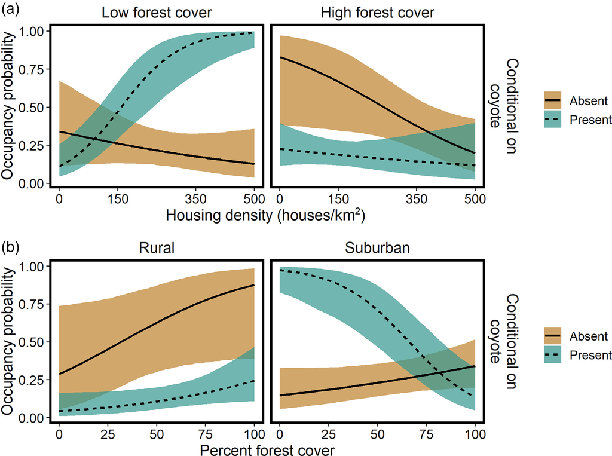

# Movtivation

- Permit inference on site-level conditions (e.g., elevation, forest type) that may influence variation in probability of presence
- Permit inference on detection-level conditions (e.g., date, temperature) that may influence your ability to detect a species
- Permit inference on whether presence of one species influences the presence of other species
- Perform multiple regressions to simultaneously account for occupancy, detection, and interactions

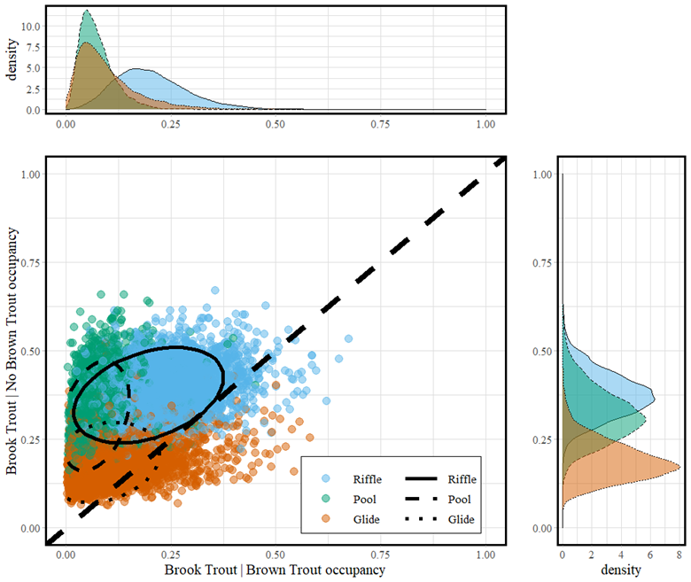

# Motivation

We focus solely on occupancy model developed in Rota et al. 2016, Methods and Ecology and Evolution (https://doi.org/10.1111/2041-210X.12587), and papers that have spawned from that one:

- Clipp et al 2021, Ecology (https://doi.org/10.1002/ecy.3520)
- Kellner et al. 2022, Journal of Agricultural, Biological, and Environmental Statistics (https://link.springer.com/article/10.1007/s13253-021-00482-y)

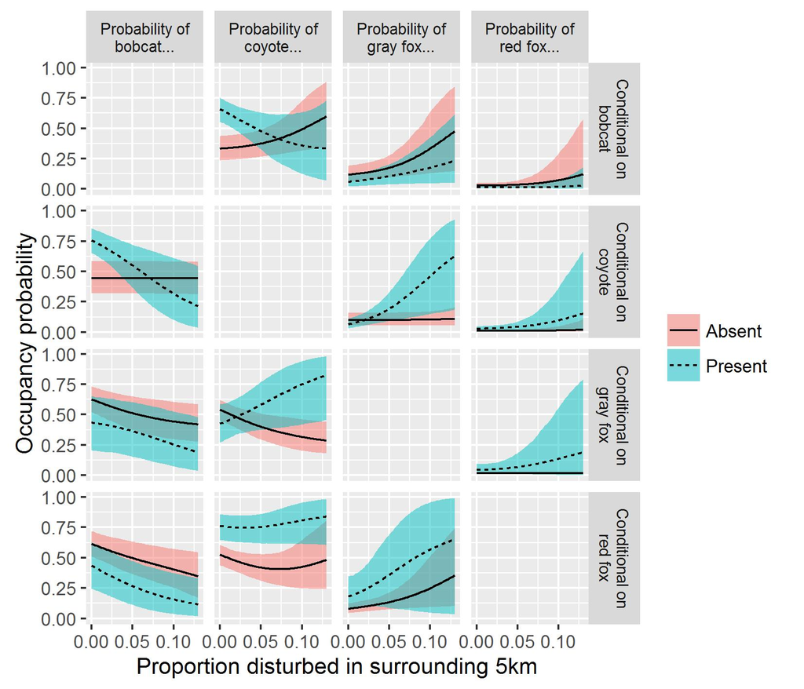

# Published Methods

- Waddle et al. 2010, Ecological Applications (https://doi.org/10.1890/09-0850.1)
- One of the first multi-species occupancy models
- Assumed dominant / subordinate species

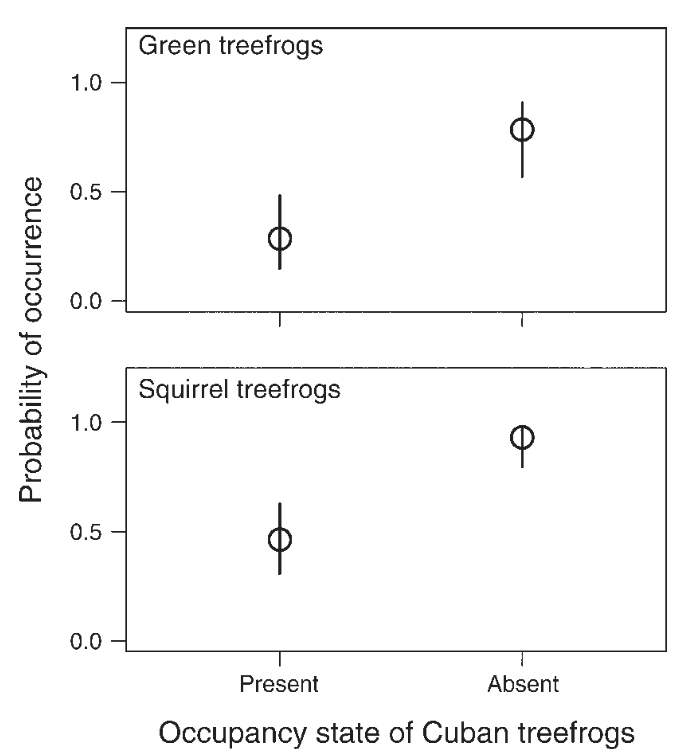

# Published Methods

- Pollock et al. 2014, Methods in Ecology and Evolution (https://doi.org/10.1111/2041-210X.12180)
- Does not account for imperfect detection
- Can include lots of interacting species
- Pairwise species interactions via covariance matrix

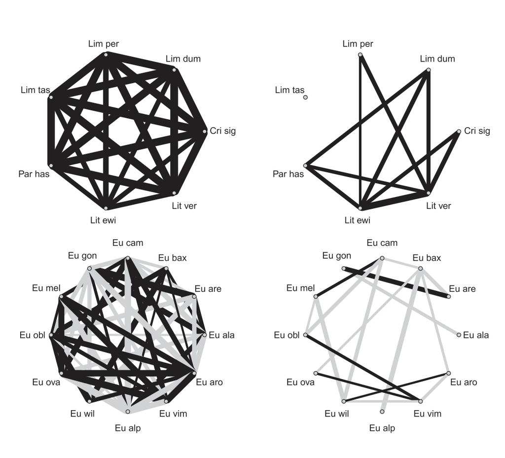

# Published Methods

- Zipkin et al. 2010, Biological Conservation (https://doi.org/10.1016/j.biocon.2009.11.016)
- Doser et al. 2022, Methods in Ecology and Evolution (https://doi.org/10.1111/2041-210X.13897)
- Random effects approach to multi-species occupancy models
- Can accommodate many species
- No explicit term for species interactions

[figure not shown]

# Published Methods

How does Rota et al. 2016 and derivatives stand out in such a crowded field?

- Does not require asymmetric interactions
- Accounts for imperfect detection
- Explicitly models pairwise species interactions
- Can model pariwise interactions as a function of covariates

My two cents … best for a relatively small number of species when interactions may vary along a gradient.

# Sampling Design

Accounting for imperfect detection requires replicate detection / non-detection surveys at each site. Basic sampling protocols include:

- Select *N* sample units
  - point count locations
  - spotlight survey along stream transect
- At sample unit *i*, conduct $J_i$ replicate surveys
  - conduct $J_i$ point count surveys at site *i*
  - conduct $J_i$ spotlight surveys at site *i*
- During survey *j* at site *i*, record detection / non-detection of $S$ species of interest
  - let $y_{sij} \in (0, 1)$ represent detection (1) or non-detection(0) of species $s$ at site *i* during replicate survey *j*

# We can obtain covariates at both the site-level and the replicate observation level

- **Site-level covariates**: These are variables that change across each sample unit. These variables are assumed constant across all replicate surveys at each site, e.g., forest type, elevation, aspect, etc. These are used in your regression for probability of presence.
- **Detection covariates**: These are variables that change during each replicate survey, e.g., temperature, time of day, wind speed, etc. These variables are used in your regression for detection probability.
- Not all covariates have to be the same for all species

# Model Description

- To keep the presentation tractable, we will present a 2-species occupancy model
- Note that this model is generalizable to more than 2 species
- A key difference between single-species and multi-species occupancy models is we now simultaneously consider latent presence / absence of multiple species
- For example, if we consider only 2 species, we can have the following latent states:

$$\boldsymbol{Z} \in \{11, 10, 01, 00 \}$$

- In order, the latent states are:
  - both species present (11)
  - species 1 present, species 2 absent (10)
  - species 1 absent, species 2 present (01)
  - both species absent (00)
- In general, there are $2^S$ potential occupancy states, where $S$ is the number of species in your model.
  - e.g., for a 3 species model, there are $2^S = 8$ potential occupancy states

# Model Description

- We can write a model for the latent occupancy state as:

$$\boldsymbol{Z} \sim \text{Multivariate Bernoulli}(\boldsymbol{\Psi})$$

- $\boldsymbol{\Psi}$ is a vector of the same length as $\boldsymbol{Z}$

$$\boldsymbol{\Psi} \equiv
\begin{bmatrix}
\psi_{11} & \psi_{10} & \psi_{01} & \psi_{00}
\end{bmatrix}$$

- Each element of $\boldsymbol{\Psi}$ describes the probability of each of the possible combinations of species presence / absence

$$\begin{align}
\psi_{11} = \text{Pr}(\boldsymbol{Z} = 11) \\
\psi_{10} = \text{Pr}(\boldsymbol{Z} = 10) \\
\psi_{01} = \text{Pr}(\boldsymbol{Z} = 01) \\
\psi_{00} = \text{Pr}(\boldsymbol{Z} = 00)
\end{align}$$

- Since $\boldsymbol{\Psi}$ describes all possible presence / absence states, the sum of its elements = 1:

$$\sum \boldsymbol{\Psi} = \psi_{11} + \psi_{10} + \psi_{01} + \psi_{00} =
1$$

- Calculating each unique probability requires specification of ‘natural paramters’, which we define next.

# Natural Parameters

- The probability of each of these occupancy states can be calculated as a function of so-called ‘natural parameters’
- For a 2-species model, we have 3 natural parameters:
  - Log odds that species 1 is present, conditional on absence of species 2 (denoted $f_1$)
  - Log odds that species 2 is present, conditional on absence of species 1 (denoted $f_2$)
  - Change in log odds of occurrence if the other species is present (denoted $f_{12}$)
- In general, there can be up to $2^S-1$ natural parameters
  - For example, a 3-species model can have 7 natural parameters
  - 3 of those natural parameters describe the log odds of single species occupancy
  - 3 of those natural parameters describe 2-way interactions ($f_{12}$, $f_{13}$, $f_{23}$)
  - 1 natural parameter describes 3-way interaction ($f_{123}$)
  - And so on where there are more than 3 species

# Probability of Presence

- Now that we’ve introduced natural parameters, we can use them to calculate the probability of each of the latent occurrence states.
- Below I present occupancy probabilities for the 2-species case:

$$\begin{align}
\psi_{11} = \frac{\text{exp}(f_1 + f_2 + f_{12})}{1 + \text{exp}(f_1) +
\text{exp}(f_2) + \text{exp}(f_1 + f_2 + f_{12})} \\
\psi_{10} = \frac{\text{exp}(f_1)}{1 + \text{exp}(f_1) + \text{exp}(f_2)
+ \text{exp}(f_1 + f_2 + f_{12})} \\
\psi_{01} = \frac{\text{exp}(f_2)}{1 + \text{exp}(f_1) + \text{exp}(f_2)
+ \text{exp}(f_1 + f_2 + f_{12})} \\
\psi_{00} = \frac{1}{1 + \text{exp}(f_1) + \text{exp}(f_2) +
\text{exp}(f_1 + f_2 + f_{12})}
\end{align}$$

- Notice the pattern in the numerator:
  - The probability that only one species is present ($\psi_{10}, \psi_{01}$) include only the natural parameter associated with that species ($f_1$ or $f_2$)
  - The probability that both species are present ($\psi_{11}$) includes both single-species ($f_1$ and $f_2$) and 2-species natural parameters ($f_{12}$)
- This is the *inverse multinomial logit link*.

# Regressions

- The natural parameters can be expressed as regressions:

$$\begin{align}
f_1 = \alpha_0 + \alpha_1u \\
f_2 = \beta_0 + \beta_1v \\
f_{12} = \gamma_0 + \gamma_1w
\end{align}$$

- The above expressions are meant to convey the ideas that:
  - regression coefficients are unique for each natural parameters
  - natural parameters do not need to be modeled as a function of the same predictor variables
- Multi-species occupancy model output is expressed in terms of natural parameters and their coefficients. It’s important to be able to relate these back to the probability of presence defined in the previous slide

# Interpreting Regressions

- Single-species natural parameters are expressed in terms of log odds of species presence, conditional on the absence of the other species

$$\begin{align}
f_1 = \alpha_0 + \alpha_1v \\
f_2 = \beta_0 + \beta_1w
\end{align}$$

- Intercept parameters are the log odds each species is present, conditional on the absence of the other species, when predictor variables are fixed at 0.
- Slope coefficients are the change in log odds each species is present, conditional on the absence of the other species, associated with a 1-unit change in the predictor

# Interpreting Regressions

- The 2-way natural parameter describes the change in log odds either species is present when the other species is also present:

$$f_{12} = \gamma_0 + \gamma_1x$$

- The intercept of this model is the change in log odds either species is present when the other species is also present, when predictor variables are fixed at 0
- Hypothesis tests of the intercept can tell us if species occur independently at sites
  - $H_0$ is that $\gamma_0 = 0$.
  - If we fail to reject $H_0$, species are independent (when all predictors = 0)
  - If we reject $H_0$, presence of one species depends on the presence of the other
- Slope coefficients tell us the change in $f_{12}$ associated with a 1-unit change in the predictor variable.

# Detection Model

- Recall that we can write a model for latent presence-absence of species as:

$$\boldsymbol{Z}_i \sim \text{Multivariate Bernoulli}(\boldsymbol{\Psi}_i)$$

where the latent occupancy state $\boldsymbol{Z}_i$ at site $i$ can be:

$$\boldsymbol{Z}_i \in \{11, 10, 01, 00 \}$$

- We can define latent occupancy of each species (little $z$) as follows:

$$\begin{align}
z_{1i} = 1 \text{ if } \{ \boldsymbol{Z}_i = 11 \text{ or }
\boldsymbol{Z}_i = 10 \} \\
z_{2i} = 1 \text{ if } \{ \boldsymbol{Z}_i = 11 \text{ or }
\boldsymbol{Z}_i = 01 \} \\
\end{align}$$

- This permits us to write a detection model as:

$$\begin{align}
y_{sij} \sim & \text{Bernoulli}(p_{sij}z_{si}) \\
p_{sij} = & \text{ logit}^{-1}(\delta_{s0} + \delta_{s1}x_{sij})
\end{align}$$

# Multi-species Occupancy Model

Ok, that was a lot, spread among a lot of slides. Here is the full 2-species model, all in one place:

$$\begin{align}
\boldsymbol{Z}_i & \sim \text{Multivariate Bernoulli}(\psi_{11} ,
\psi_{10}, \psi_{01}, \psi_{00}) \\
y_{sij} & \sim \text{Bernoulli}(p_{sij}z_{si}) \\
\psi_{11} & = \frac{\text{exp}(f_1 + f_2 + f_{12})}{1 +
\text{exp}(f_1) + \text{exp}(f_2) + \text{exp}(f_1 + f_2 + f_{12})} \\
\psi_{10} & = \frac{\text{exp}(f_1)}{1 + \text{exp}(f_1) +
\text{exp}(f_2) + \text{exp}(f_1 + f_2 + f_{12})} \\
\psi_{01} & = \frac{\text{exp}(f_2)}{1 + \text{exp}(f_1) +
\text{exp}(f_2) + \text{exp}(f_1 + f_2 + f_{12})} \\
\psi_{00} & = \frac{1}{1 + \text{exp}(f_1) + \text{exp}(f_2) +
\text{exp}(f_1 + f_2 + f_{12})} \\
f_1 & = \alpha_0 + \alpha_1u \\
f_2 & = \beta_0 + \beta_1v \\
f_{12} & = \gamma_0 + \gamma_1w \\
p_{sij} & = \text{logit}^{-1}(\delta_{s0} + \delta_{s1}x_{sij})
\end{align}$$

# Note – Occupancy Model as Categorical Random Variable

An equivalent way to model the latent occupancy state is as a categorical random variable:

$$\boldsymbol{Z} \sim \text{Categorical} (\boldsymbol{\Psi})$$

In this case, we could allow $\boldsymbol{Z}$ to take integer values representing combinations of presence / absence:

$$\boldsymbol{Z} \in \{1,2,3,4 \}$$

- In this situation, you might define elements of $\boldsymbol{Z}$ as:
  - 1: both species present (11)
  - 2: species 1 present, species 2 absent (10)
  - 3: species 1 absent, species 2 present (01)
  - 4: both species absent (00)

The actual numeric code associated with each combination of presence / absence is not important, as long as you conduct proper book-keeping when calculating $\boldsymbol{\Psi}$

# Marginal Occupancy Probability

- In statistics, a *marginal probability* is the probability one event occurs, regardless of whether the other event occurs
- Recall that all the probabilities we calculate are for a particular latent occupancy state, and a particular species may be present over many different occupancy states.
  - for example, species 1 may be present if $\boldsymbol{Z} = 11$ or $\boldsymbol{Z} = 10$
- There is often interest in estimating *marginal* occupancy probability of a particular species that doesn’t depend on the presence or absence of another species

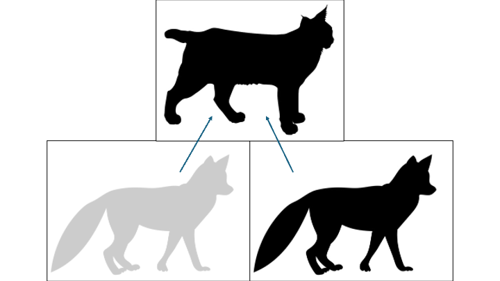

# Marginal Occupancy Probability

Calculating marginal occupancy probability of one species involves summing over all possible values of the other. We can write the probability of any combination of 1 and 0 as:

$$f(z_1,z_2) =
\psi_{11}^{z_1z_2}\psi_{10}^{z_1(1-z_2)}\psi_{01}^{(1-z_1)z_2}\psi_{00}^{(1-z_1)(1-z_2)}$$

We obtain the marginal probability of occurrence of species 1 by summing over all possible values of species 2:

$$\begin{align}
f(z_1) = & \sum_{z_2 = 0}^1
\psi_{11}^{z_1z_2}\psi_{10}^{z_1(1-z_2)}\psi_{01}^{(1-z_1)z_2}\psi_{00}^{(1-z_1)(1-z_2)}
\\
= &\psi_{11}^{z_1}\psi_{01}^{(1-z_1)} +
\psi_{10}^{z_1}\psi_{00}^{(1-z_1)}
\end{align}$$

The probability species 1 is present is then:

$$Pr(z_1=1) = \psi_{11}+\psi_{10}$$

Using the same method, we can also calculate the marginal probability species 2 is present as:

$$Pr(z_2=1) = \psi_{11} + \psi_{01}$$

# Conditional Occupancy Probability

- In statistics, a *conditional probability* is defined as the probability that an event occurs, given that some other event also occurs
- In this context, we’re often interested in estimating that probability that one species occurs at a site, given that another species is present (or absent)

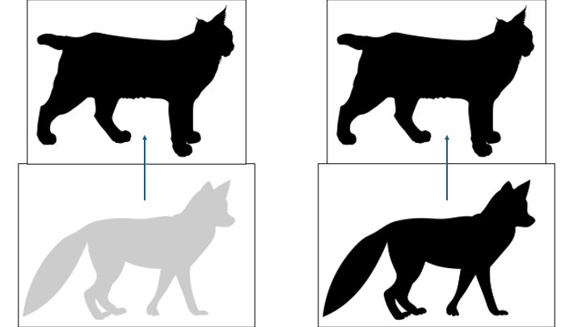

# Conditional Occupancy Probability

- A general method for calculating conditional probabilities is to divide the probability of the joint event occurring by the marginal probability that the conditioning event occurs:

$$P(A|B) = \frac{P(A \cap B )}{P(B)}$$

- In the previous slides, I demonstrate how to calculate marginal probabilities.
- The joint event will be the probability of the specific presence / absence of interest and will be a subset of the marginal event.
- For example, the probability species 1 is present, conditional on the presence of species 2, can be calculated as:

$$\psi_{1|2} = \frac{\psi_{11}}{\psi_{11} + \psi_{01}}$$

- In this example, the joint event is both species occurring together (which occurs with probability $\psi_{11}$)
- The conditioning event is that species 2 is present (which occurs with probability $\psi_{11} + \psi_{01}$)

# Conditional Occupancy Probability

- We can use rules of conditional probability to show that the single-species natural parameters represent the log odds of species occurrence, conditional on the absence of the other species.
- Let’s calculate the marginal probability species 1 occurs, conditional on the absence of species 2.
- The marginal probability that species 2 is *absent* can be calculated as:

$$(1 - \psi_2) = \psi_{10} + \psi_{00}$$

- The joint event is that species 1 is present, and species 2 is absent ($\psi_{10}$)
- We can calculate the conditional probability as:

$$\psi_{1|-2} = \frac{\psi_{10}}{\psi_{10} + \psi_{00}}$$

- We can further substitute elements of the inverse multinomial link into this equation:

$$\begin{align}
\psi_{1|-2} = & \bigg( \frac{\text{exp}(f_1)}{1 + \text{exp}(f_1) +
\text{exp}(f_2) + \text{exp}(f_1 + f_2 + f_{12})} \bigg) \times \\
& \bigg( \frac{1 + \text{exp}(f_1) + \text{exp}(f_2) +
\text{exp}(f_1 + f_2 + f_{12})}{1 + \text{exp}(f_1)} \bigg) \\
= & \frac{\text{exp}(f_1)}{1 + \text{exp}(f_1)}
\end{align}$$

which follows our definition of $f_1$ as the log odds species 1 occupies a site, conditional on the absence of species 2.

# On the agenda

- This afternoon: multi-species occupancy models in Unmarked
- Tomorrow morning: multi-species occupancy models in NIMBLE
- Tomorrow afternoon: multi-species occupancy models with continuous-time detection (in Stan)